# EXPERIMENT 9

jayu1294@gmail.com

2022-05-06

## Aim

1. To fit a binomial distribution to the given data

## Packages used and syntax of R methods

Functions from `stat` package (which is loaded by default).

## Algorithm

- Step 1: Assign the inputs for required fitting model
- Step 2: Calculate the theoretical frequencies
- Step 3: Visualize the observed distribution and theoretical distribution
- Step 4: Compare the difference in orginal and fitted distributions

> *Case:* The following data shows the result of throwing 12 fair dice 4,096 times; a throw of 4,5, or 6 being called success.

$\begin{array}{|l|ccccccccccccc|}\hline \text{Success(X)}:& 0 &1& 2& 3& 4 &5& 6& 7& 8& 9& 10& 11& 12\\\hline \text{Frequency(f)}:& 0 &7& 60& 198& 430& 731& 948& 847& 536& 257& 71& 11& 0\\\hline \end{array}$

Fit a binomial distribution and find the expected frequencies. Compare the graphs of the observed frequency and theoretical frequency.

## R code

```r
# create input parameters
p=3/6
Observed=c(0 ,7, 60,198,430,731,948,847,536, 257, 71,11, 0)
success=seq(0,12,1)
N=sum(Observed)
```

### Theoretical distribution

```r
#calculating theoretical frequencies
TF=round(N*dbinom(success,size=12,prob=p),2)
TF
```

```
##  [1]   1  12  66 220 495 792 924 792 495 220  66  12   1
```

### Plotting the observed and theoretical frequencies

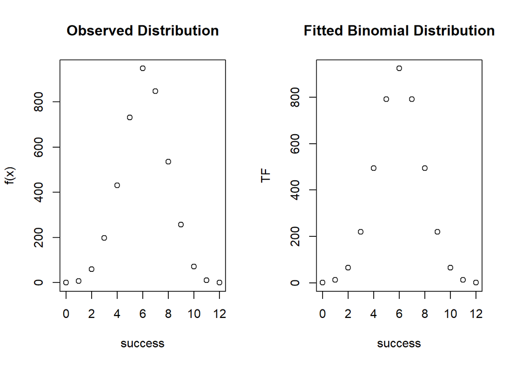

```r
par(mfrow=c(1,2))
plot(success,Observed,xlab="success",ylab="f(x)")
title("Observed Distribution")
plot(success,TF,xlab="success",ylab="TF")
title("Fitted Binomial Distribution")
```

### Fitting table

```r
Fit=data.frame(Success=success,Observed,Fitted_binom=TF)
knitr::kable(
  Fit, caption = 'The binomial fitting table',
  booktabs = TRUE)
```

The binomial fitting table

| Success | Observed | Fitted_binom |
| --- | --- | --- |
| 0 | 0 | 1 |
| 1 | 7 | 12 |
| 2 | 60 | 66 |
| 3 | 198 | 220 |
| 4 | 430 | 495 |
| 5 | 731 | 792 |
| 6 | 948 | 924 |
| 7 | 847 | 792 |
| 8 | 536 | 495 |
| 9 | 257 | 220 |
| 10 | 71 | 66 |
| 11 | 11 | 12 |
| 12 | 0 | 1 |

## Results & discussions

Given arbitrary distribution is mapped into the framework of a binomial distribution.